# A3: Incarceration

### Introduction

In the US black and brown folks are disproportionally incarcerated at a much higher rate than their white counterparts. This has to do with a lack of a fair trial and questionable policing. I will be analyzing the year to see any trends. I will also analyze population rates from all races to see if any racial disparity arise.

### Summary Information

What is the total black prison population? The total black prison population is: 12113359.

What is the total of male population in prison? The total male prison population is: 25189045

Which state has the highest AAPI prison population? The state with the highest AAPI prison population is: HI.

What is the year with the most females in prison? The year with the most female prison population is: 1998.

Which year has the most male prison population? The year with the most male prison population is: 2007.

### The Dataset

Who collected the data? The data was collected by the Vera Institute for Justice. How was the data collected or generated? The data was collected by merging data they found with original jail sets in order to examine both jail and prison incarceration.

Why was the data collected? This data was collected to see demographic disparities that arise and any relevant trends. There is divided justice in the US therefore it is important to study that as well. How many observations (rows) are in your data?  
How many features (columns) are in the data?

There are more than 250 rows in my data and more than 10 columns.

What, if any, ethical questions or questions of power do you need to consider when working with this data?

I would consider these questions when working with the data. Are these numbers accurate? Why are there lots of black incarcerations that does not seem accurate? What are the population differences between racial groups?

What are possible limitations or problems with this data? (at least 200 words)

Some possible limitations are problems with this data is that there are a lot of null values in the table. This might be an issue since it might not give me an accurate number of what I want to calculate. Additionally there could be more people in jail/prison than what is presented in the dataset. The US justice system is flawed and we don’t know the reasons for which individuals are incarcerated for whatever reason. These numbers could also be skewed and lead to misinterpreting the message. There are not alot of data of minorities in prison which could be challenging. Minorities have a lower population however they mostly have null values. Therefore they are not accurately represented in the dataset.

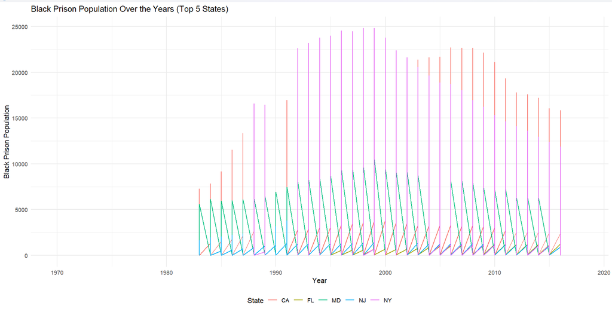

```r
#top_states <- state_avg_black_pop[order(state_avg_black_pop$black_prison_pop, decreasing = TRUE), ]
#top_states <- head(top_states, 5)

#prison_top_states <- subset(prisoncountystate, state %in% top_states$state)

#ggplot(prison_top_states, aes(x = year, y = black_prison_pop, color = state)) +
  #geom_line() +
  #labs(title = "Black Prison Population Over the Years (Top 5 States)",
#       x = "Year",
#       y = "Black Prison Population",
#       color = "State") +
#  theme_minimal() +
#  theme(legend.position = "bottom center")
```

### Variable Comparison Chart

[figure not shown]

```r
#ggplot(prisoncountystate, aes(x = year)) +
#geom_line(aes(y = black_prison_pop, color = "Black Prison #Population")) +
#labs(title = "Comparison of Black and White Prison Populations",
#       x = "Year",
#       y = "Population",
#       color = "Population Group") +
#  scale_color_manual(values = c("Black Prison Population" = "purple", "White Prison Population" = "red"))
```

### Map

[figure not shown]

```r
#ggplot() +
#  geom_sf(data = jailpop_states, aes(fill = male_adult_jail_pop))
#  scale_fill_gradient(low = "white", high = "black") +
 # labs(title = "Male Adult Jail Population by State",
 #      fill = "Male Adult Jail Population") +
#  theme_void()
```